# COMPSCIX 415.2 Homework 9/Final

Lian Shen

March 30, 2019

Load libraries

```r
library(tidyverse)
library(broom)
```

## **Exercise 1 - Sampling Distributions, Functions and For Loops (10 points)**

**Recall that the distribution of the sample mean is approximately a Normal distribution, and that the standard error is p/sqrt(n). This holds true regardless of the distribution of our population.**  
**For this problem, assume that the number of miles that a particular car can run before its battery wears out is exponentially distributed with an average of 10,000 miles.**  
**The exponential distribution has a rate parameter that controls how quickly the distribution decays and defines what the mean and standard deviation will be. In our case the rate = 1/10000, the mean = 10000 and the standard deviation = 10000.**

**STEP 1**  
**Write an R function that does the following:**  
**• Takes a sample of size samp_size from this exponential distribution (samp_size is an input parameter for the function)**  
**• Calculates the mean of that sample**  
**• Calculates the standard deviation of that sample**  
**• Returns the calculated mean and standard deviation as a list**  
**Helper code**

```r
samp_fun <- function(samp_size, samp_rate) {
  #...your code here...
  # take sample
  samp <- rexp(n = samp_size, rate = samp_rate)
  # calculate mean and standard deviation
  samp_avg <- mean(samp)
  samp_std_dev <- sd(samp)

  stats <- list(samp_avg = samp_avg, samp_std_dev = samp_std_dev)
  return(stats)
}
```

**STEP 2**  
**Then write a loop that does this:**  
**• Runs the above function 1000 times, with samp_size = 50 and samp_rate = 1/10000**  
**• Saves all of the sample means in a vector called sample_means, and all of the sample standard deviations in a vector called sample_sds**

```r
n <- 10000
samp_size <- 50
samp_rate <- 1/10000
samp_means <- rep(NA, n)
samp_sds <- rep(NA, n)

for (i in 1:n){
  samp_stats <- samp_fun(samp_size, samp_rate)
  samp_means[i] <- samp_stats$samp_avg
  samp_sds[i] <- samp_stats$samp_std_dev
}
```

**STEP 3**  
**Then**  
**• plot your sample means as a histogram**

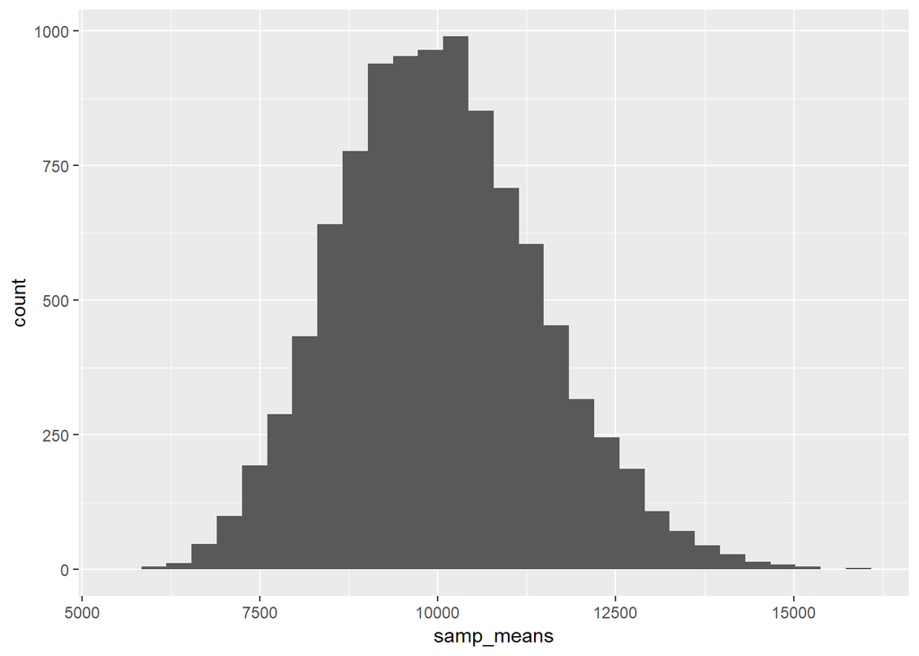

```r
samp_means_tibble <- tibble(samp_means)
samp_means_tibble %>% ggplot() + geom_histogram(aes(x = samp_means))
```

**• output the standard deviation of your sample means**

```r
sd(samp_means)
```

```
## [1] 1426.018
```

**• calculate the theoretical standard error (p = 10000, n = sample size)**

```r
10000/samp_size
```

```
## [1] 200
```

**• calculate the mean of the sample standard deviations and use this to calculate the empirical standard error**

```r
mean_samp_sds <- mean(samp_sds)
mean_samp_sds/samp_size
```

```
## [1] 196.1169
```

**STEP 4**  
**Repeat STEP 2 and STEP 3 using a sample size of 5000.**

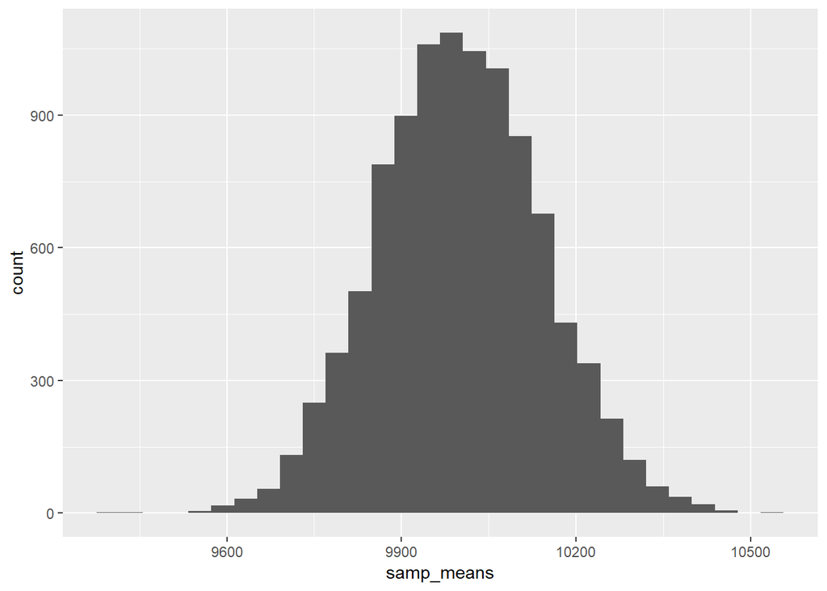

```r
n <- 10000
samp_size <- 5000
samp_rate <- 1/10000
samp_means <- rep(NA, n)
samp_sds <- rep(NA, n)

for (i in 1:n){
  samp_stats <- samp_fun(samp_size, samp_rate)
  samp_means[i] <- samp_stats$samp_avg
  samp_sds[i] <- samp_stats$samp_std_dev
}

samp_means_tibble <- tibble(samp_means)
samp_means_tibble %>% ggplot() + geom_histogram(aes(x = samp_means))
```

```r
sd(samp_means)
```

```
## [1] 140.94
```

```r
10000/samp_size
```

```
## [1] 2
```

```r
mean_samp_sds <- mean(samp_sds)
mean_samp_sds/samp_size
```

```
## [1] 2.000371
```

## **Exercise 2 - Linear Regression (5 points)**

**For this exercise we will return to the House Prices prediction dataset that we used for HW 7. You should have already downloaded the train.csv dataset before, but if you didn’t you can download it from Canvas in this week’s module.**  
**Load the train.csv dataset into R and fit a regression model with:**  
**• y = SalePrice**  
**• Features: LotArea, OverallQual, and ExterQual**

```r
filepath <- "C:\\Users\\lshen\\Documents\\Data Science\\train.csv"
train_data <- read_csv(file = filepath)
train_data_lm <- lm(SalePrice ~ LotArea + OverallQual + ExterQual, data = train_data)
```

**Answer these questions:**  
**• Use the broom package to output the coefficients and the R-squared**

```r
# coefficients
tidy(train_data_lm) %>% select(term, estimate)
```

```
## # A tibble: 6 x 2
##   term         estimate
##   <chr>           <dbl>
## 1 (Intercept)  40764.
## 2 LotArea          1.45
## 3 OverallQual  34466.
## 4 ExterQualFa -95352.
## 5 ExterQualGd -71529.
## 6 ExterQualTA -97527.
```

```r
# R-squared
glance(train_data_lm) %>% select(r.squared, adj.r.squared)
```

```
## # A tibble: 1 x 2
##   r.squared adj.r.squared
##       <dbl>         <dbl>
## 1     0.695         0.694
```

**• Interpret the coefficient on LotArea**  
For every increase in unit LotArea, there is increase on average of 1.453 unit in SalePrice.

**• Interpret the coefficient on ExterQualGd**  
Good quality exterior material is on average 71529.49 units less than Excellent quality in SalePrice.

**• Compare this model to the model we fit in HW 7 with GrLivArea, OverallQual, Neighborhood. Which is the better fitting model?**

```r
homework7_lm <- lm(formula = SalePrice ~ GrLivArea + OverallQual + Neighborhood, data = train_data)
glance(homework7_lm)
```

```
## # A tibble: 1 x 11
##   r.squared adj.r.squared  sigma statistic p.value    df  logLik    AIC
##       <dbl>         <dbl>  <dbl>     <dbl>   <dbl> <int>   <dbl>  <dbl>
## 1     0.787         0.783 37009.      203.       0    27 -17416. 34887.
## # ... with 3 more variables: BIC <dbl>, deviance <dbl>, df.residual <int>
```

Based on the R-squared value for linear fit, homework 7’s features were better fitting since its R-squared value was higher.

## **Exercise 3 - AB Testing (5 points)**

**Download the ab_test_data.csv file from Canvas. This file contains two columns: version and conversion. Each row is a visitor to a webpage. The version column tells us which version of the webpage the visitor saw, and the conversion column is a binary value and equals 1 if the visitor converted (0 otherwise).**  
**We want to perform an AB test on this data to see if the conversion rates are different for the two versions of the webpage.**

```r
filepath <- "C:\\Users\\lshen\\Documents\\Data Science\\ab_test_data.csv"
ab_data <- read_csv(file = filepath)
```

**Answer these questions:**  
**a. What proportion of visitors converted for each version of the webpage?**

```r
ab_data %>% group_by(version) %>% summarize(proportion = mean(conversion))
```

```
## # A tibble: 2 x 2
##   version proportion
##   <chr>        <dbl>
## 1 A           0.0415
## 2 B           0.1
```

A proportion of 4.15% converted for version A and 10% converted for version B.

**b. Perform the AB test in R. What is the p-value for the AB test (hypothesis test of proportions)?**

```r
samp_a <- 0.0415
samp_b <- 0.1
# get sample size
ab_data %>% group_by(version) %>% summarize(n())
```

```
## # A tibble: 2 x 2
##   version `n()`
##   <chr>   <int>
## 1 A        2000
## 2 B        2000
```

```r
two_prop_test <- prop.test(c(samp_a, samp_b), c(2000, 2000))
two_prop_test$p.value
```

```
## [1] 1
```